# M5_Lab4

Emily Shepherd

2023-02-04

# The Data

The data I chose was used to determine stroke risk based on eleven indicators. It is a large data set, so I chose to focus the visualizations on single women who lived in urban areas. I chose this data set because I am interested in health-related data.

# The Bubble Plot

My visualization has age plotted along the x-axis, average glucose level plotted on the y-axis. The size of the points are determined by BMI. Additionally, the color of each bubble was determined whether the woman never smoked, formerly smoked, or is currently a smoker.

I chose to choose the colors manually. I avoided reds and greens because they are hard to discern by many people. The colors I chose were goldenrod4 (Formerly smoked), darkorchid4 (Never Smoked), and cadetblue (Smokes.) I chose the background panel to be azure, because I thought it went with the general palette.

There were three main differences between my bubbleplot and the one constructed in the demo. First, I manually chose the colors. Second, I formatted the text in the legend, so it was not the variable names, but what the variables represented. Lastly, I manually determined the theme to be used by choosing the background and grid colors.

From the plot, there did not appear to be a strong relationship among age, average glucose level, and bmi. However, I did notice that there were very few older smokers in the plot. I decided to explore this relationship with a boxplot.

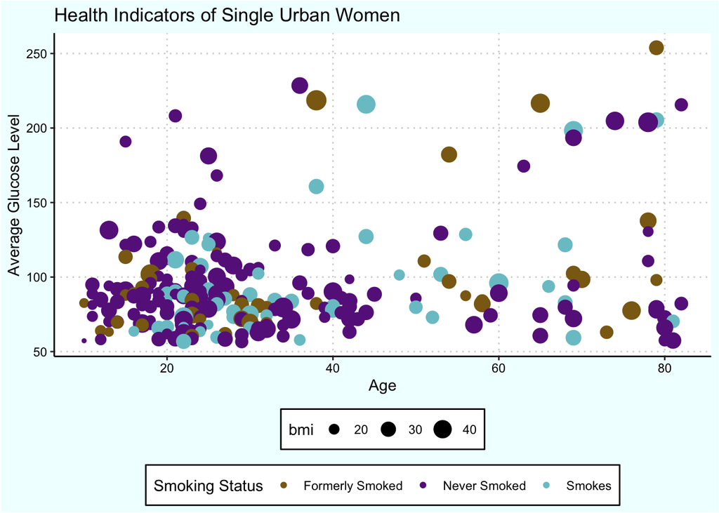

# The Boxplot

One way in which my boxplot differed from the one in the demonstration is that I chose to use ggplot to create it. I plotted smoking status along the x-axis and age along the y-axis. I chose to create the outline cadetblue and the fill azure. Part of the reasoning that I did this was so it would coordinate with the bubbleplot. Instead of manually choosing my theme, I picked theme_classic(), because it is clean and easy to read. I changed the notch width to 0.5.

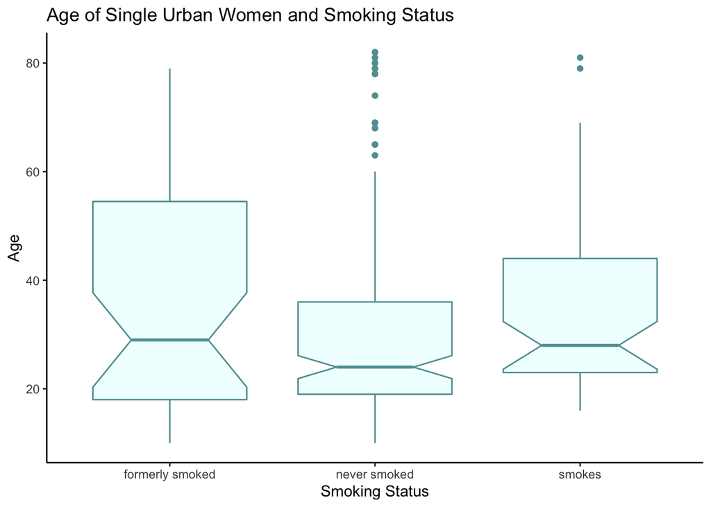